# Implimenting Popular ML Algorithms in R: Workshop

Katie Sasso

November 18, 2017

## The Boston Housing Dataset

This data set contains information collected by the U.S Census Service concerning housing in the area of Boston Mass.

```r
library(MASS)
library(caret)
boston <- Boston
str(boston)
```

```
## 'data.frame':    506 obs. of  14 variables:
##  $ crim   : num  0.00632 0.02731 0.02729 0.03237 0.06905 ...
##  $ zn     : num  18 0 0 0 0 0 12.5 12.5 12.5 12.5 ...
##  $ indus  : num  2.31 7.07 7.07 2.18 2.18 2.18 7.87 7.87 7.87 7.87 ...
##  $ chas   : int  0 0 0 0 0 0 0 0 0 0 ...
##  $ nox    : num  0.538 0.469 0.469 0.458 0.458 0.458 0.524 0.524 0.524 0.524 ...
##  $ rm     : num  6.58 6.42 7.18 7 7.15 ...
##  $ age    : num  65.2 78.9 61.1 45.8 54.2 58.7 66.6 96.1 100 85.9 ...
##  $ dis    : num  4.09 4.97 4.97 6.06 6.06 ...
##  $ rad    : int  1 2 2 3 3 3 5 5 5 5 ...
##  $ tax    : num  296 242 242 222 222 222 311 311 311 311 ...
##  $ ptratio: num  15.3 17.8 17.8 18.7 18.7 18.7 15.2 15.2 15.2 15.2 ...
##  $ black  : num  397 397 393 395 397 ...
##  $ lstat  : num  4.98 9.14 4.03 2.94 5.33 ...
##  $ medv   : num  24 21.6 34.7 33.4 36.2 28.7 22.9 27.1 16.5 18.9 ...
```

The Boston data frame contains the following variables:

- **crim**: per capita crime rate by town.
- **zn**: proportion of residential land zoned for lots over 25,000 sq.ft.
- **indus**: proportion of non-retail business acres per town.
- **chas**: Charles River dummy variable (= 1 if tract bounds river; 0 otherwise).
- **nox**: nitrogen oxides concentration (parts per 10 million).
- **rm**: average number of rooms per dwelling.
- **age**: proportion of owner-occupied units built prior to 1940.
- **dis**: weighted mean of distances to five Boston employment centres.
- **rad**: index of accessibility to radial highways.
- **tax**: full-value property-tax rate per $10,000.
- **ptratio**: pupil-teacher ratio by town.
- **black**: 1000(Bk - 0.63)^2 where Bk is the proportion of African-Americans by town.
- **lstat**: lower status of the population (percent).
- **medv**: median value of owner-occupied homes in $1000s.
  - Prices are not in error - data is from the 70s

**We will use various methods to predict the median value of owner-occupied homes in $1000s (medv)**

### Data Checks

```r
library(purrr)
map_dbl(boston, ~sum(is.na(.)))
```

```
##    crim      zn   indus    chas     nox      rm     age     dis     rad
##       0       0       0       0       0       0       0       0       0
##     tax ptratio   black   lstat    medv
##       0       0       0       0       0
```

```r
# if there were NAs we would need to deal with this in an appropriate manner (list-wise deletion, multiple imputation, etc.)

#Inspect the range of medv
summary(boston$medv)
```

```
##    Min. 1st Qu.  Median    Mean 3rd Qu.    Max.
##    5.00   17.02   21.20   22.53   25.00   50.00
```

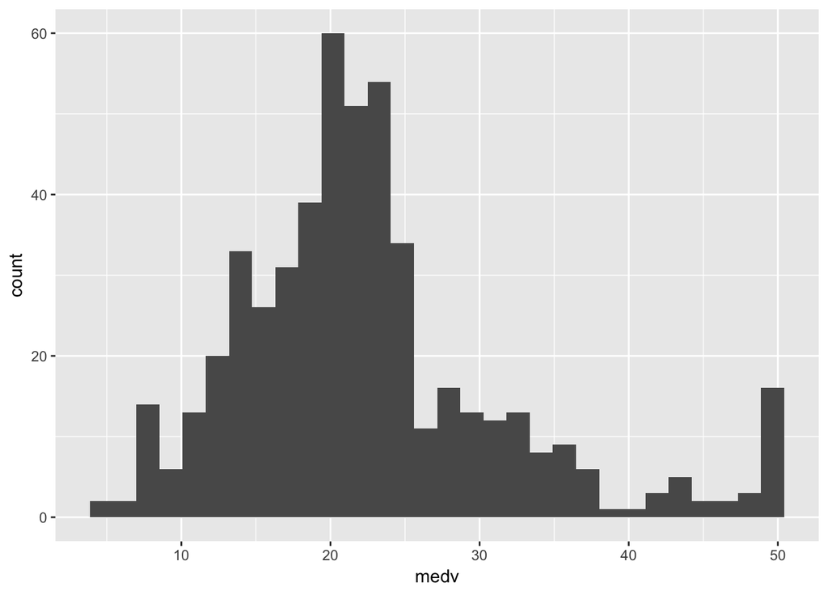

```r
library(ggplot2)
ggplot(boston, aes(medv)) + geom_histogram(bins = 30)
```

## Tools

One quick and easy way to start tackling various machine learning problems is to use a package, like Caret or Scikit (Python) that provide a uniform interface to functions from many different ML libraries/packages:

- These packages provide standardized functions for common tasks (i.e., training, prediction, tuning, variable importance)
- Allow you to quickly and easily compare the performance of multiple algorithms

**Cost of Convenience**:

- All tuning parameters available for a given model (i.e., function) may not be immediately obvious when called from packages like these
  - e.g., ntree in randomForest package - you can tune it from within caret but have to do so somewhat manually
- Important data pre-processing steps for various models/functions may not be as apparent as they are in the source package documentation
  - e.g., pre-processing of factor/categorical variables in xgboost
- Always wise to be familiar with the function’s source documentation

### The Caret Package in R

[interactive chart not shown]

### Scikit in Python

[interactive chart not shown]

## Data Splitting and Pre-processing

```r
# configure multicore - OPTIONAL
# if parallel backend is loaded and available functions that use it will do so.
# can turn this off in "trainControl" function or simply do  no load parallel backend into session
library(caret)
library(doParallel)
cl <- makeCluster(detectCores()-1)
registerDoParallel(cl)


# use caret’s createDataPartition() function to partition the data into training (70%) and test sets (30%).

seed = set.seed(42)
# ?createDataPartition
index <- createDataPartition(boston$medv, p = 0.7, list = FALSE)
#multiple arguments we can use to customize and create balanced splits of the data. I.e., we can could change the groups argument to adjust the percentile based section that sampling is done within
#We could split based on the predictors, customize splitting for timeseries, or split with consideration to important groups
train <- boston[index, ]
test  <- boston[-index, ]
```

Several other pre-processing steps may be needed depending on your data and the model used. Caret, for example, provides a broad overview of the usual [pre-processing essentials](https://topepo.github.io/caret/pre-processing.html#creating-dummy-variables).

Some common cases to look out for:

- Zero- and Near Zero-Variance Predictors
- Transforming predictors
- Correlated predictors
- Converting factors/categorical variables to Dummy Variables (i.e., one-hot encoding)
  - If your categorical variable happens to be type integer or numeric (i.e., chas, rad in boston) this may or may not be necessary depending on the number of categories, your question of interest, and what the integer reflects
  - *chas* variable in our examples is already set up as a dummy variable
  - We are going to choose to treat the *rad* variable (i.e., index of accessibility to radial highways) as numeric since it reflects incremental levels of accessibility to the highway
  - if the numbers were not meaningful (i.e., value of 2 was not further from highway than 1) we would want to dummy code this variable

```r
# several functions available for dummy coding - here is one from Caret package
# NOTE we would want to do this before train/test split
library(dplyr)
table(boston$rad)
```

```
##
##   1   2   3   4   5   6   7   8  24
##  20  24  38 110 115  26  17  24 132
```

```r
boston_dummy <- boston %>%
  mutate(rad = as.factor(rad))

dummies <- dummyVars(medv ~., data = boston_dummy)
boston_dummy <- as.data.frame(predict(dummies, newdata = boston_dummy))

head(boston_dummy)
```

```
##      crim zn indus chas   nox    rm  age    dis rad.1 rad.2 rad.3 rad.4
## 1 0.00632 18  2.31    0 0.538 6.575 65.2 4.0900     1     0     0     0
## 2 0.02731  0  7.07    0 0.469 6.421 78.9 4.9671     0     1     0     0
## 3 0.02729  0  7.07    0 0.469 7.185 61.1 4.9671     0     1     0     0
## 4 0.03237  0  2.18    0 0.458 6.998 45.8 6.0622     0     0     1     0
## 5 0.06905  0  2.18    0 0.458 7.147 54.2 6.0622     0     0     1     0
## 6 0.02985  0  2.18    0 0.458 6.430 58.7 6.0622     0     0     1     0
##   rad.5 rad.6 rad.7 rad.8 rad.24 tax ptratio  black lstat
## 1     0     0     0     0      0 296    15.3 396.90  4.98
## 2     0     0     0     0      0 242    17.8 396.90  9.14
## 3     0     0     0     0      0 242    17.8 392.83  4.03
## 4     0     0     0     0      0 222    18.7 394.63  2.94
## 5     0     0     0     0      0 222    18.7 396.90  5.33
## 6     0     0     0     0      0 222    18.7 394.12  5.21
```